# Local Dependence

Youjin Lee

- Local Dependence
- Motivating Example
- Simple Block Models
- Three Blocks Models
- Five Blocks Models

## Local Dependence

The dependence induced by a probability measure $\textbf{P}$ is called local if there exists a partition of the set of nodes $\mathcal{A}$ into $K \geq 2$ non-empty, finite subsets $\mathcal{A}_{1}, ... , \mathcal{A}_{k}$, called neighborhoods, such that within- and between-neighborhoold subgraphs $\textbf{Y}_{k,l}$ within domains $\mathcal{A}_{k} \times \mathcal{A}_{l}$ and sample spaces $Y_{k,l}$ satisfy, for all $y_{k,l}:$

$\textbf{P}_{K}(Y) = \prod\limits_{k=1}^{K} P_{k,k}(Y_{k,k}) \prod\limits_{l=1}^{k-1} P_{k,l}(Y_{k,l}, Y_{l,k})$

and a suitable neighborhood structure is needed. Let $Z = (Z_{1}, ... , Z_{n})$ be memebership indicators, where for $Z_{i} = (z_{i1}, z_{i2},...,z_{iK})$, $z_{ik} = 1$ if node $i$ is member of neighborghood $\mathcal{A}_{k}$ and $z_{ik} = 0$ otherwise. We assume that the conditional probability mass function (PMF) of a random graph $Y$ given neighborhood structure $Z = z$ can be written as:

$P(Y=y|Z=z) = \prod\limits_{k=1}^{K} P(Y_{k,k} = y_{k,k} | Z_{z}) \times \prod\limits_{l=1}^{k-1}P(Y_{k,l} = y_{k,l}, Y_{l,k} = y_{l,k} | Z = z)$

Assume that a pair of nodes with similar values is more likely to be in the same neighborhood (same membership), and the probability of having an edge within the block is larger than the probability between the blocks.

## Motivating Example

I start with the following model:

- Distribution of Attributes

$Y_{i} \overset{i.i.d}{\sim} N(0,1), i = 1,...,n.$

- Create $K$ neighborhood :

$Z_{i} \sim Multinomial(\textbf{p} =p_{1}, .. , p_{k}), i = 1,... ,n$ and make sure that $\textbf{P} = f(Y_{i})$

- Within block probability

Suppose $X_{ij} \sim Bernoulli(g(X_{ij}))$ such that $X_{ij} = 1$ iff there exists an edge between node $i$ and node $j$, and $X_{ij} = 0$ otherwise.

$g(X_{ij}) = \left\{ \begin{array}{ll} w_{i} & i = j\mbox{ (within block)} \\ b_{ij} = b_{ji} & i \neq j\mbox{ (between blocks)} \end{array} \right.$

We want to test independence between a graph $G$ and its nodes’ attributes $Y:$

$H_{0} : f_{G \cdot Y} = f_{G} \cdot f_{Y}$

- $K = 3$ blocks

$Z_{i} \sim \left\{ \begin{array}{ll} Multinom(0.5, 0.25, 0.25) & Y_{i} <= -1 \\ Multinom(0.25, 0.5, 0.25) & -1 < Y_{i} \leq 1 \\ Multinom(0.25, 0.25, 0.5) & Y_{i} > 1 \end{array} \right.$

$\left\{ \begin{array}{lll} w_{1} = 0.8 & w_{2} = 0.6 & w_{3} = 0.4 \\ b_{ij} = 0 & \forall i \neq j \end{array} \right.$

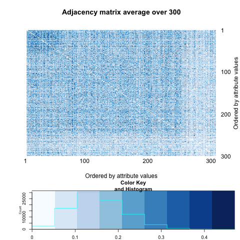

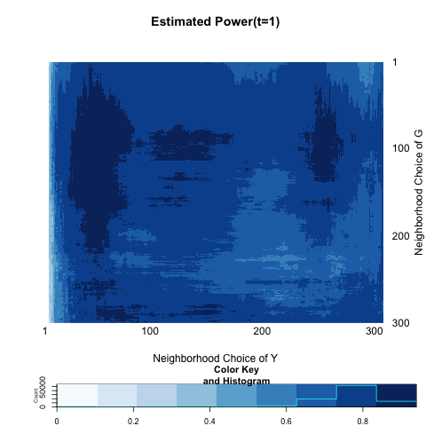

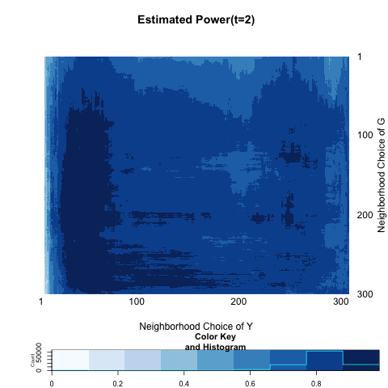

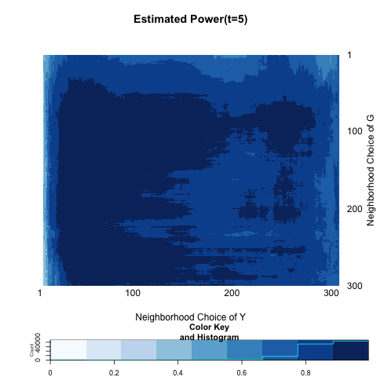

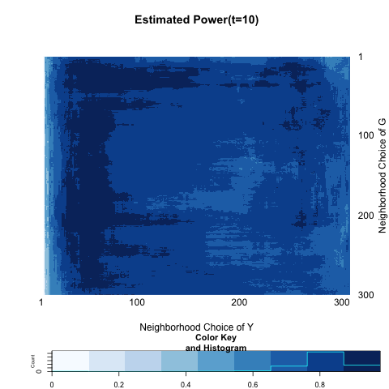

|  | t=1 | t=2 | t=5 | t=10 |
| --- | --- | --- | --- | --- |
| global test | 0.74 | 0.78 | 0.75 | 0.74 |
| local optimal | 0.94 | 0.99 | 1.00 | 0.98 |

- $K = 5$ blocks according to quantile on $Y$(attribute variable).

$\left\{ \begin{array}{lll} w_{i} = 0.3 & \forall{i} \\ b_{ij} = 0 & \forall i \neq j \end{array} \right.$

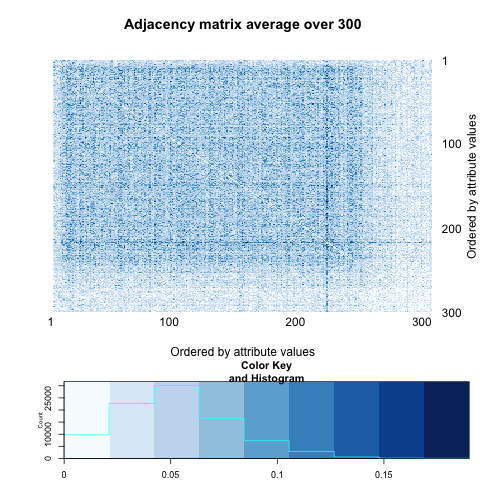

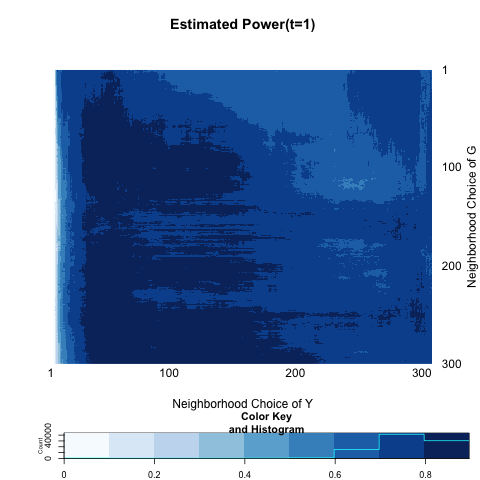

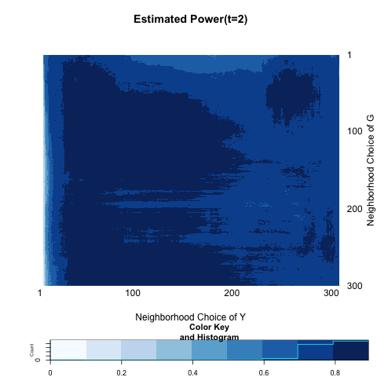

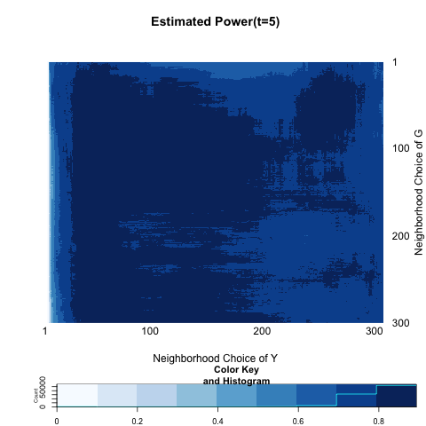

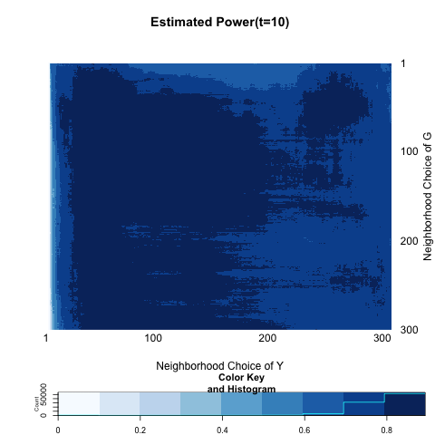

|  | t=1 | t=2 | t=5 | t=10 |
| --- | --- | --- | --- | --- |
| global test | 0.75 | 0.76 | 0.75 | 0.76 |
| local optimal | 0.90 | 0.89 | 0.89 | 0.89 |

It looks like for the above cases, the optimal neighborhood choice is more dependent on the choice of $Y$ (node attributes) rather than that of $G$ (network).

## Simple Block Models

We can think of two-block models which divide the observations into two neighborhood, or blocks. We will introduce a variable $Z$ which indicate block membership.

$Z_{i} = \left\{ \begin{array}{ll} -1 & i \in \mbox{ block 1 } \\ 1 & i \in \mbox{ block 2} \end{array} \right.$

Generate a Bernoulli random variable which depends on block membership and a parameter $\omega.$

$X_{i} \overset{i.i.d}{\sim} Bern(0.5 + z_{i} \omega)$

Note that larger value of $\omega$ implies much discrepency between blocks. The probability of having an edge also depends on the block membership.

$A = \left[ \begin{array}{c|c} p & q \\ \hline q & p \end{array} \right]$

First I sepecify $n=100$ ; $p = 0.3$ ; $q = 0.05.$

- $\omega =0$

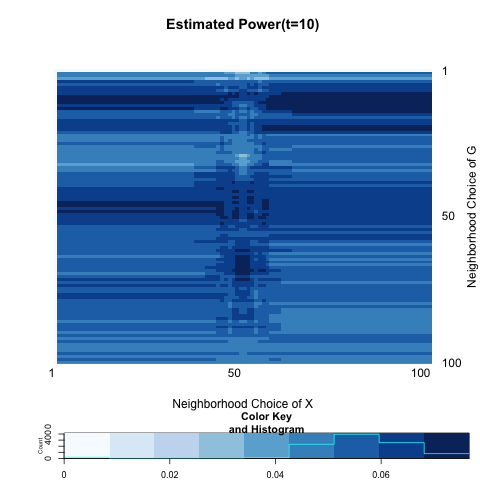

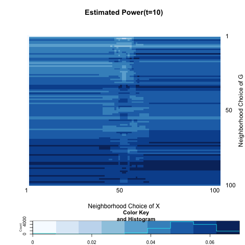

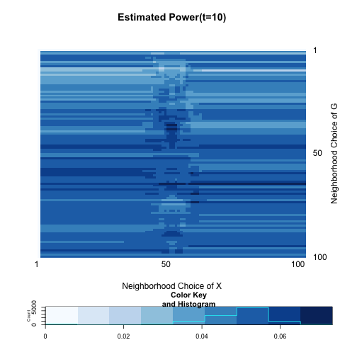

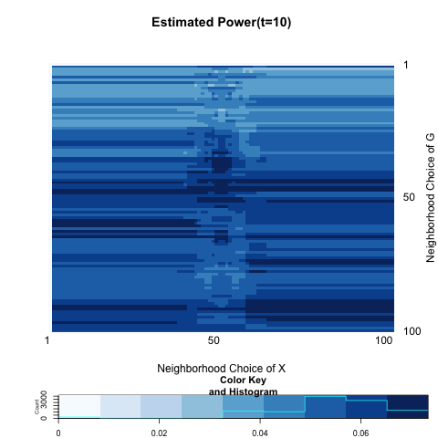

|  | t=1 | t=2 | t=5 | t=10 |
| --- | --- | --- | --- | --- |
| global test | 0.05 | 0.05 | 0.05 | 0.06 |
| local optimal | 0.08 | 0.07 | 0.07 | 0.07 |

- $\omega = 0.10$

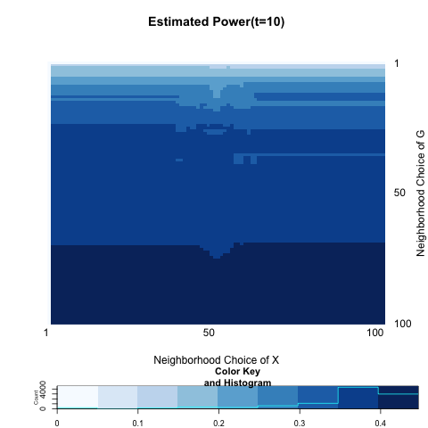

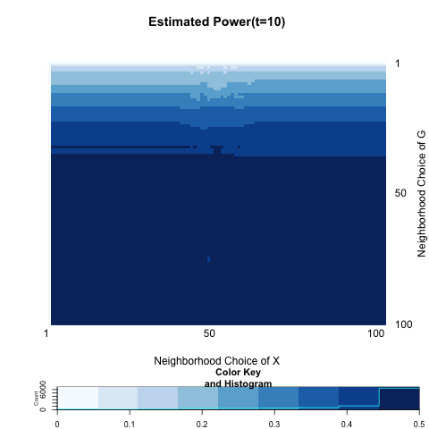

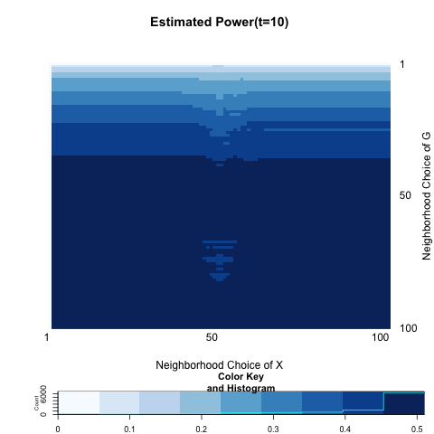

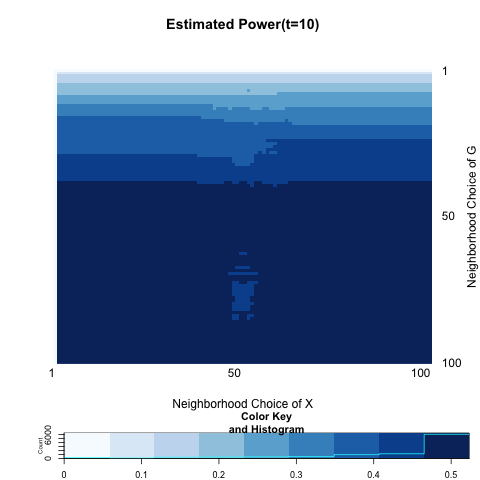

|  | t=1 | t=2 | t=5 | t=10 |
| --- | --- | --- | --- | --- |
| global test | 0.44 | 0.48 | 0.50 | 0.52 |
| local optimal | 0.45 | 0.50 | 0.51 | 0.52 |

- $\omega = 0.20$

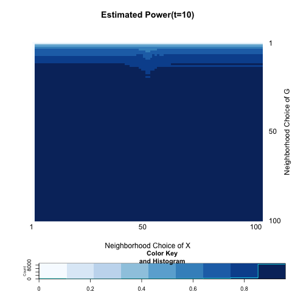

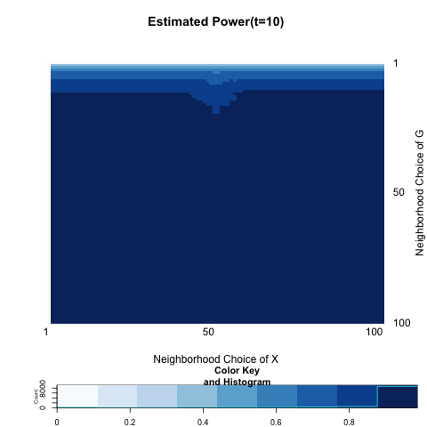

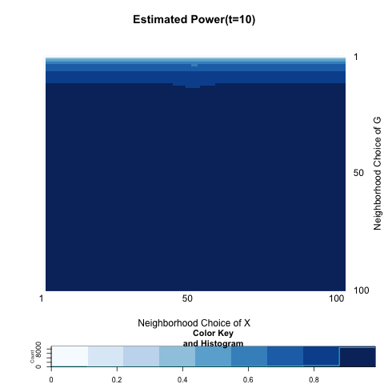

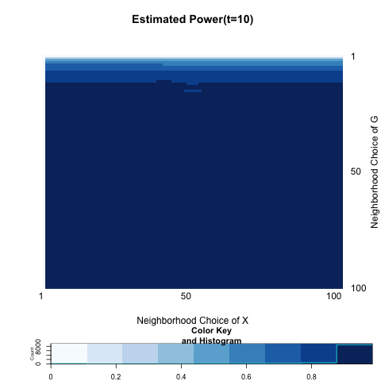

|  | t=1 | t=2 | t=5 | t=10 |
| --- | --- | --- | --- | --- |
| global test | 0.96 | 0.98 | 0.98 | 0.98 |
| local optimal | 0.96 | 0.99 | 0.99 | 0.99 |

## Three Blocks Models

We can think of two-block models which divide the observations into two neighborhood, or blocks. We will introduce a variable $Z$ which indicate block membership.

$Z_{i} = \left\{ \begin{array}{ll} -1 & i \in \mbox{ block 1 } \\ 1 & i \in \mbox{ block 2} \\ 0 & i \in \mbox{ block 3} \end{array} \right.$

Generate a Bernoulli random variable which depends on block membership and a parameter $\omega.$

$X_{i} \overset{i.i.d}{\sim} Bern(0.5 + z_{i} \omega)$

Note that larger value of $\omega$ implies much discrepency between blocks. The probability of having an edge also depends on the block membership.

$A = \left[ \begin{array}{c|c | c} p & q & q \\ \hline q & p & q \\ \hline q & q & p \end{array} \right]$

Remind that our testing hypothesis is independence between network or graph $G$ and its nodes’ attributes $X:$

$H_{0} : f_{G \cdot X} = f_{G} \cdot f_{X}$

Set $n=150$ ; $p = 0.3$ ; $q = 0.05;$ $\omega = 0.15$. In other words, the probability of having edges between or within block is:

$A = \left[ \begin{array}{c|c| c} 0.3 & 0.05 & 0 + \epsilon \\ \hline 0.05 & 0.3 & 0.05 \\ \hline 0 + \epsilon & 0.05 & 0.3 \end{array} \right]$

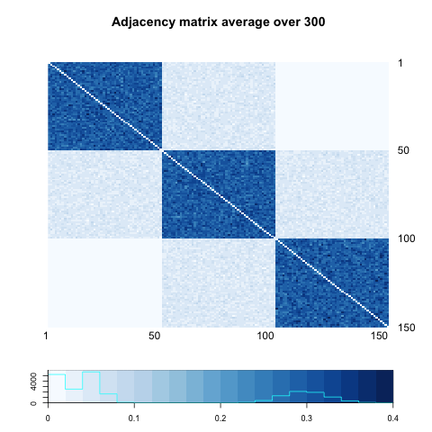

and corresponding nodes’ attributes are following such Bernoulli models :

$X = \left[ \begin{array}{c|c|c} Bern(0.35 ) & & \\ \hline & Bern(0.65) & \\ \hline & & Bern(0.50) \end{array} \right]$

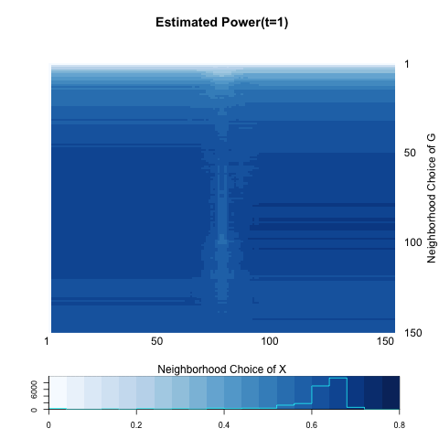

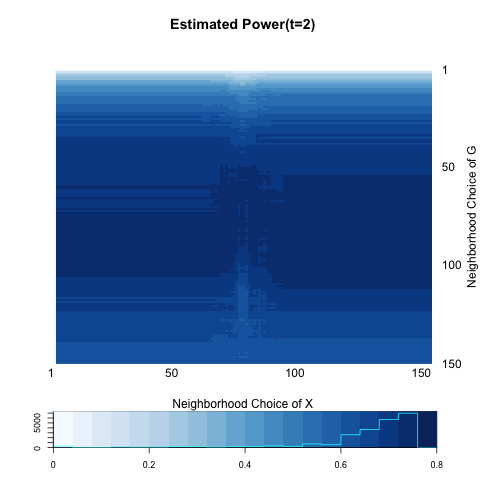

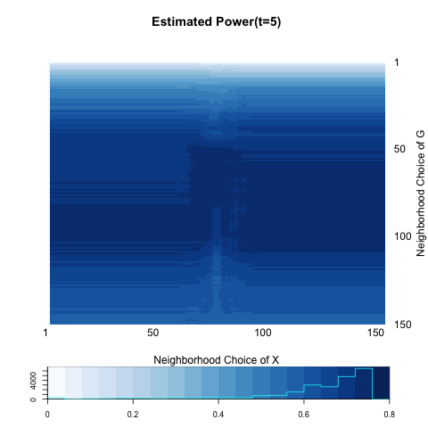

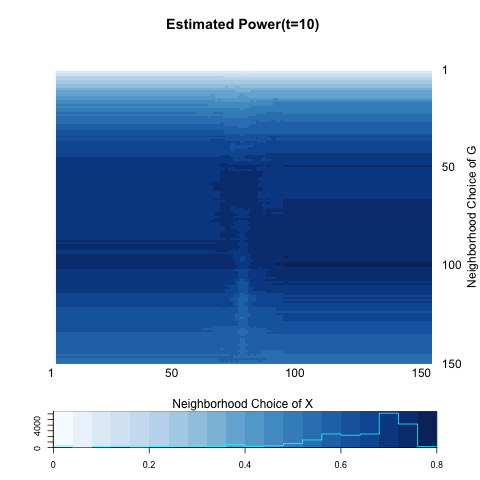

|  | t=1 | t=2 | t=5 | t=10 |
| --- | --- | --- | --- | --- |
| global test | 0.63 | 0.61 | 0.56 | 0.54 |
| local optimal | 0.65 | 0.72 | 0.73 | 0.74 |

As diffusion time increases, estimated power from global test is decreasing while that from the local optimal increases. This does not work when the number of blocks is two and when $p > q$, global test achieves highest power because the distance between blocks is always proportion to the discrepancy in distributions.

On the other hand, when the number of blocks is three, the local scale in (double-centered) $G$ (graph) is stuck in between about 50-100. That means including the one neighboring block is okay while two neighboring blocks, which would be equivalent to global scale does not provide the most powerful test statistics. It makes sense in that for each block, two other block is equally likely to be diffuse but the distribution is different. In case of `block1` and `block2`, including two other blocks supports increasing diffusion distance induces increasing disrepancy in distribution. On the other hand, for `block3`, two other neighboring blocks are correlated in opposite directions.

Consider the other case where the between-block probabilities differ but still being less than the within-block probability.

$A = \left[ \begin{array}{c|c| c} 0.30 & 0.20 & 0.05 \\ \hline 0.20 & 0.30 & 0.10 \\ \hline 0.05 & 0.10 & 0.30 \end{array} \right]$

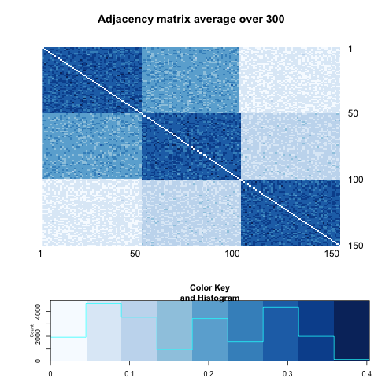

and corresponding nodes’ attributes are following such Bernoulli models :

$X = \left[ \begin{array}{c|c|c} Bern(0.35) & & \\ \hline & Bern(0.65) & \\ \hline & & Bern(0.50) \end{array} \right]$

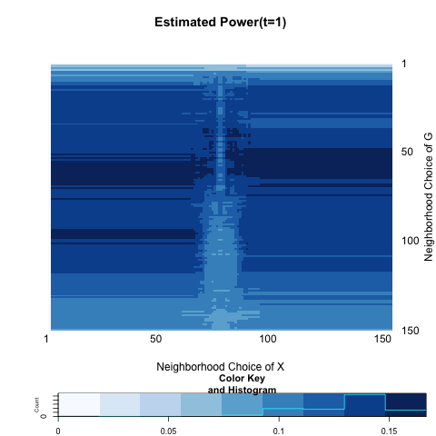

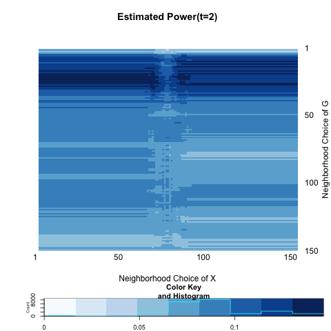

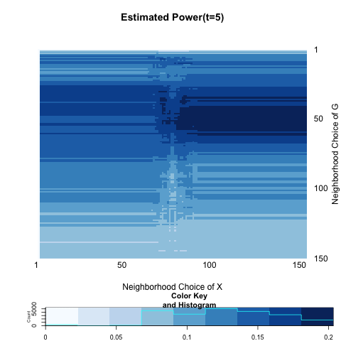

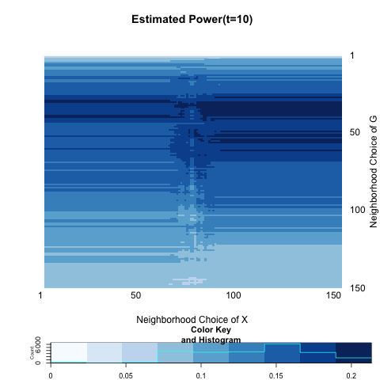

|  | t=1 | t=2 | t=5 | t=10 |
| --- | --- | --- | --- | --- |
| global test | 0.09 | 0.06 | 0.08 | 0.08 |
| local optimal | 0.17 | 0.15 | 0.20 | 0.21 |

In this case, the choice of neighborhood becomes much narrower than the previous one. It seems including only one block is the optimal. Also note that the global test almost results independence.